# 10 Numeric integration with Julia

### 10.4.2 Simpson’s rule

The trapezoid rule can be viewed as a simple linear approximation to the function $f(x)$ over the subinterval $[a, b]$. That is, replace the function with the secant line between these two values and integrate the replacement. With this viewpoint, it is possible that other easy-to-integrate function approximations will lead to improved approximate integrals. Simpson’s method can be viewed in just this way. It replaces $f$ by the parabola going through $(a, f(a))$, $(c, f( c))$ and $(b, f(b))$ where $c=(a+b)/2$ is the midpoint between $a$ and $b$.

We compare how accurate we get with this rule for the same `f` as before:

```julia
simpsons_r = [riemann(f, 0, 1, n, method="simpsons") for n in ns];
[ns (1).-left_r (1).-trapezoid_r (1).-simpsons_r]
```

```
5×4 Matrix{Float64}:
     10.0  -0.26665      -0.01665      -4.16667e-6
    100.0  -0.0251667    -0.000166665  -4.16667e-10
   1000.0  -0.00250167   -1.66667e-6   -4.15223e-14
  10000.0  -0.000250017  -1.66667e-8    1.22125e-15
 100000.0  -2.50002e-5   -1.66664e-10   1.22125e-15
```

As can be seen, for this function approximating with a parabola is much quicker to converge. That is, $n$ can be smaller yet the same accuracy is maintained. (Of course, there are more computations involved for each, so the number of operations needed may or may not be fewer, that would require some analysis.)

### 10.4.3 Error

It can be shown that the [error for Simpson’s method](http://en.wikipedia.org/wiki/Simpson%27s_rule#Error) is bounded by

$$\frac{1}{90}\frac{1}{2^5} M (b-a)^5 \frac{1}{n^4},$$

where $M$ is a bound on the fourth derivative. As we increase $n$, the error gets small at a quick rate. By contrast, the error for the trapezoid method will be like $n^{-2}$ and the left Riemann sum like $n^{-1}$.

### 10.4.4 Practice

#### Question

The trapezoid rule has no error for linear functions and Simpson’s rule has no error for quadratic functions. Verify the latter by computing the following:

```julia
f(x) = x^2; F(x) = x^3/3
riemann(f, 0, 10, 100, method="simpsons") - (F(10) - F(0))
```

```
5.684341886080802e-14
```

How accurate is the approximation? Around

`1e-8`

`1e-10`

`1e-12`

`1e-14`

`1e-16`

`0`

#### Question

Compare the difference between the trapezoid rule and Simpson’s rule when integrating $\cos(x)$ from $0$ to $\pi/6$. How big is the difference when $n=10,000$?

```julia
a, b, n = 0, pi/6, 10_000
riemann(cos, a, b, n, method="trapezoid") - riemann(cos, a, b, n, method="simpsons")
```

```
-1.1423328949433653e-10
```

How big is the difference?

`1e-8`

`1e-10`

`1e-12`

`1e-14`

`1e-16`

`0`

#### Question ….

Using Simpson’s rule and `n=1000` compute the integral of $f(x) = 1/(1+x^2)$ between $0$ and $1$.

## 10.5 The quadgk function

`Julia` provides the `quadgk` function to do adaptive Gauss-Konrod quadrature, a modern, fast and accurate means to compute 1-dimensional integrals numerically. This is in the `QuadGK` package which is loaded with `MTH229`.

The use is straightforward, and similar to `riemann` above: you specify a function object, and the limits of integration. You don’t specify $n$—as this is computed adaptively—but you can optionally specify a tolerance which controls the accuracy, though we don’t do so here. For example, a typical usage might be:

```julia
a, err = quadgk(sin, 0, pi)     ## 2 is exact
```

```
(2.0000000000000004, 1.7901236049056024e-12)
```

If just the answer is of interest, then it can be extracted using *index notation* or `first`:

```julia
first(quadgk(sin, 0, pi))       # `first` returns first component of container
```

```
2.0000000000000004
```

For another illustration, since Archimedes the known answer for $\int_0^1 x^2 dx$ is $1/3$. We see that `quadgk` gets it right for all the digits:

```julia
quadgk(x -> x^2, 0, 1)
```

```
(0.3333333333333333, 0.0)
```

The `riemann` function is good for pedagogical purposes, but the `quadgk` function should be used instead of the `riemann` function – besides being part of a standard package for `Julia` it is more accurate, more robust, fast, and less work to use.

(That `quadgk` is exact with polynomials is no surprise, as the underlying choice of nodes and weights makes it so for polynomials of certain degree.)

### 10.5.1 Practice

#### Question: Use quadgk

Let $f(x) = \exp(-4 \cdot |x-1/2|)$. Find the integral over $[0,1]$ using `quadgk`:

#### Question: use quadgk

Let $f(x) = \sin(100\pi x)/(\pi x)$. Find the integral over $[0,1]$ using `quadgk`:

#### Question

Let $f(x) = \sin(100\pi x)/(\pi x)$. Using $1,000$ points, find the right-Riemann integral over $[0,1]$.

(The answer via Riemann sums isn’t even correct to 4 decimal points, due to the highly oscillatory nature of the function.)

#### Question

How far off is this Riemann estimate, when $n=100,000$?

```julia
f(x) = 1/(1 + x^4)
quadgk(f, 0, 1)[1] - riemann(f, 0, 1, 100_000);
```

Roughly `1e-12`

Roughly `1e-6`

Roughly `1e-4`

#### Question

The `quadgk` function allows you to specify issues where there are troubles. For example, we know that $f(x) = \sin(x)/x$ has an issue at 0. Directly trying this integral `quadgk(x->sin(x)/x, -pi, pi)` will fail, but you can specify the issue at $0$ as follows `quadgk(x -> sin(x)/x, -pi, 0, pi)`. Do so. What is the value of the result:

#### Question

Let $f(x) = |x - 0.3|^{-1/4}$. We wish to find $\int_0^1 f(x) dx$. The problem with this function is the singularity at $x=0.3$. (That is, the function is not continuous, so has no guarantee that an integral over a closed domain exists.) However, some such integrals do exist, and the `quadgk` function can integrate around such singularities by spelling them out in the domain of integration. Just specify the trouble spots between the endpoints:

```julia
f(x) = abs(x - 0.3)^(-1/4)
val = quadgk(f, 0, 0.3, 1);
```

Following the above, what answer do you get?

## 10.6 Applications

There are many more applications of the integral beyond computing areas under the curve. Here we discuss two:

- finding the volume of a figure with rotational symmetry (a glass in our example) and
- finding the arc length of a line.

In each case one integrates a function related to the one describing the problem. If you keep this straight, the applications are no different than above.

### 10.6.1 Volume as a function of radius.

The volume of a solid of revolution about the $y$-axis is illustrated [here](https://www.khanacademy.org/math/integral-calculus/solid_revolution_topic/disc-method/v/disc-method-around-y-axis).

This figure shows a volume of revolution (a glass) with an emphasis on the radius of the solid. The volume can be determined if the radius is known.

[figure not shown]

Glass

The basic formula requires the description of the radius as a function of $x$ (if oriented as the figure) or the height, $h$, (if oriented as in real life). Suppose we specify the radius with $r(h)$, then the following formula holds with $b$ the total height.

$$V(b) = \int_0^b \pi r(h)^2 dh.$$

For a symmetrical drinking vessel, like most every glass you drink from, the volume can be computed from a formula if a function describing the radius is known. For a given glass, let $r(h)$ give the radius as a function of height. Then, as above, the volume of the vessel as a function of height, $b$, is given by an integral:

$$V(b) = \int_0^b \pi (r(h))^2 dh$$

We wish to look at our intuition relating the height of the fluid in the vessel compared to the percentage of fluid of the whole. A basic question might be: If the vessel is filled half way by height, is the volume half of the total, more or less?

The answer, of course, depends on the shape of the glass. That is the shape of the function $r(h)$. Note, if $r(h)$ is a constant – the glass is a cylinder – then the half-height mark is also the half-volume mark. Not so in general.

For a standard measuring cup, the answer for different `b`’s is printed on the side. The gap in heights between the marks for equal volumes seem to be a bit different.

[figure not shown]

Measuring cup

With the formula for the volume of a solid of revolution we can compute these marks numerically if we know the radius as a function of height.

In Glass Shape Influences Consumption Rate for [Alcoholic Beverages](http://www.plosone.org/article/info%3Adoi%2F10.1371%2Fjournal.pone.0043007) the authors demonstrate that the shape of the glass can have an effect on the rate of consumption, presumably people drink faster when they aren’t sure how much they have left. In particular, they comment that people have difficulty judging the half-finished-by-volume mark.

This figure shows some of the wide variety of beer-serving glasses:

[figure not shown]

Beer glasses—and not one traditional pint glass

We work with metric units, as there is a natural relation between volume in cm$^3$ and liquid measure (1 liter = 1000 cm$^3$, so a 16-oz pint glass is roughly $450$ cm$^3$.)

Let two glasses be given as follows. A typical pint glass with linearly increasing radius:

$$r(h) = 3 + \frac{1}{5}h, \quad 0 \leq h \leq b;$$

and a curved edge one:

$$s(h) = 3 + \log(1 + h), \quad 0 \leq h \leq b$$

[figure not shown]

Half full

One could also consider a fluted one, such as appears in the comparison noted in the article.

#### Question

Which of these functions might describe a fluted glass where the radius changes faster as the height gets bigger, that is the radius is a *concave up* function?

`r(h) = 2 + h/10, 0 <= h <= 10`

`r(h) = 2 + (h/10)^2, 0 <= h <= 10`

`r(h) = 2 + sqrt(h/10), 0 <= h <= 10`

For the two types of glasses in the figure, we create functions in `Julia` as follows:

```
r(h) = 3 + h/5
s(h) = 3 + log(1 + h)
r_vol(b) = first(quadgk(x -> pi*r(x)^2, 0, b))
s_vol(b) = first(quadgk(x -> pi*s(x)^2, 0, b))
```

```
s_vol (generic function with 1 method)
```

Then we can easily find the volume as a function of height. For example at $10$cm we have:

```
(r_vol(10), s_vol(10))
```

```
(513.1268000863328, 687.2432199897678)
```

However, to find $b$ that makes the glass $450$ cm$^3$ requires us to solve an equation involving an integral for $b$:

$$V(b) = \int_0^b \pi r(h)^2 dh = 450.$$

Not to worry, we can use `fzero` from the `Roots` package for that (again, this is loaded with the `MTH229` package). To solve for when `V(b) = r_vol(b) - 450 = 0` we have

```
r_b = fzero(x -> r_vol(x) - 450,  10)
```

```
9.168923214523724
```

So $b$ is basically $9.17$. Given this, how much volume is left at `b/2`?

```
r_vol(r_b/2)
```

```
173.27527610482957
```

Which is what percent of the whole?

```
r_vol(r_b/2) / r_vol(r_b) * 100
```

```
38.505616912184344
```

As this height is often mistaken for the half-way by volume mark, people tend to drink these pints faster than they think.

Now compare to the height to get half the volume (225 ml):

```
r_half = fzero(x -> r_vol(x) - 225,  5)
```

```
5.603662378152273
```

This value is more than half of $b$:

```
r_half / r_b
```

```
0.6111581749616989
```

At this height only half the volume is remaining (and not at 50% of the original height.)

### 10.6.2 Practice

#### Question

Compare the above for the curved glass, where $s(h) = 3 + \log(1 + h)$.

What is the height of the glass, `b`, needed to make the volume 450?

#### Question

Find the volume of the glass represented by $s(h) = 3 + \log(1 + h), 0 \leq h \leq b$ when the glass is filled to half its height. Report the value as a percentage of the total volume.

#### Question

Now how high do you fill the glass to produce *half* the volume? Report your answer in terms of a percentage of $b$, the height of the glass.

#### Question

Consider this big Solo cup:

[figure not shown]

Solo cup

It has approximate dimensions: smaller radius 5 feet, upper radius 8 feet and height 15 feet. How many gallons is it? At $8$ pounds a gallon this would be pretty heavy!

Two facts are useful:

- a cubic foot is 7.48052 gallons
- the radius as a function of height is $r(h) = 5 + (3/15)\cdot h$

## 10.7 Example, arc length

The basic indefinite integral for a positive function answers the amount of area under the curve over a given interval. However, the integral can be interpreted in many different ways. For example, one can use an integral to answer how long a curve is. Of course one can estimate this answer. For example, consider this curve:

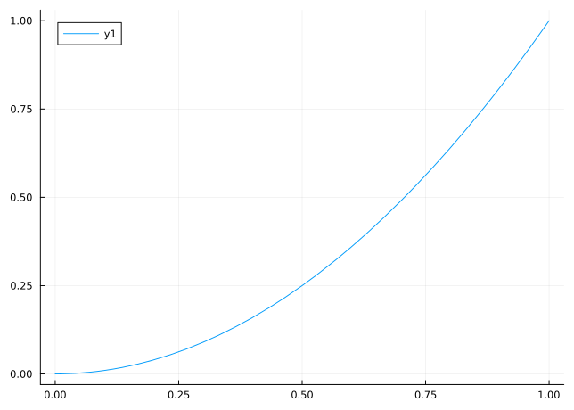

```julia
f(x) = x^2
plot(f, 0, 1)
```

This curve has length no more than $2 = 1 + 1$ – the distance along the $x$ axis starting at $0$ to $1$ and then going up. It is also longer than $\sqrt{2} = \sqrt{1^2 + 1^2}$ – the straight line distance between the two endpoints. But how long is it?

In general, the *arc length* of the curve $y=f(x)$ between $a \leq x \leq b$ (or how long is the curve) is given through the formula

$$l = \int_a^b \sqrt{1 + f'(x)^2} dx$$

The formula is from the length of the hypotenuse of a right triangle with lengths $1$ and $f'(x)$, This image suggests an approximation for the length and why the hypotenuse of some triangle might be involved.

[figure not shown]

Arc length

Rather than focus on a derivation, we do some examples illustrating that to compute the arclength of the graph of a function is relatively straightforward using numeric integration. For example, our answer for $f(x) = x^2$ is given by

```julia
f(x) = x^2
dL(x) = sqrt(1 + f'(x)^2) # using f' notation defined in MTH229
quadgk(dL, 0, 1)
```

```
(1.4789428575446002, 1.0424397123287577e-8)
```

(We use an *anonymous function* for the integrand which involved the derivative being found through `f'`. If the graph is described by `f`, then this expression be the same for all these problems.)

Whereas, the length of the $f(x) = \sin(x)$ over $[0, \pi]$ would be:

```julia
f(x) = sin(x)
dL(x) = sqrt(1 + f'(x)^2)
quadgk(dL, 0, pi)
```

```
(3.820197789027713, 9.377002729848982e-9)
```

Next we look at a more practical problem.

### 10.7.1 Example: the catenary shape

A [catenary shape](http://en.wikipedia.org/wiki/Catenary) is the shape a hanging chain will take as it is suspended between two posts. It appears elsewhere, for example, power wires will also have this shape as they are suspended between towers. A formula for a catenary can be written in terms of the hyperbolic cosine, `cosh` in `Julia` or exponentials.

$$y = a \cosh(x/a) = a \cdot \frac{e^{x/a} + e^{-x/a}}{2}.$$

Suppose we have the following wire hung between $x=-1$ and $x=1$ with $a = 2$:

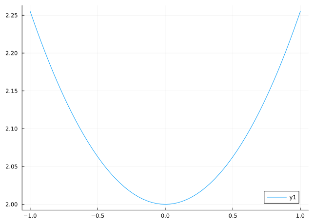

```julia
f(x; a=2) = a * cosh(x/a)
plot(f, -1, 1)
```

How long is the chain? Looking at the graph we can guess an answer is between $2$ and $2.5$, say, but it isn’t much work to get the answer:

```julia
dL(x) = sqrt(1 + f'(x)^2)
quadgk(dL, -1, 1)
```

```
(2.0843812219749895, 0.0)
```

### 10.7.2 Practice

#### Question

The sag in the chain is adjusted through the parameter $a$ – chains with larger $a$ have less sag.

Suppose your chain has parameter `a=3` what is the length? (Use `quadgk`)

#### Question: in the artist studio

This picture of Jasper Johns [Near the Lagoon](http://www.artic.edu/aic/collections/artwork/184095) was taken at The Art Institute Chicago.

[figure not shown]

{fig-alt: image of Jasper Johns Near the Lagoon showing a catenary shape}

The museum notes have

> For his Catenary series (1997–2003), of which Near the Lagoon is the largest and last work, Johns formed catenaries—a term used to describe the curve assumed by a cord suspended freely from two points—by tacking ordinary household string to the canvas or its supports.

This particular catenary has a certain length. The basic dimensions are 78in wide and 118in drop. If our shifted function is

$$f(x; a, b) = a \cosh(x/a) - b$$

Then we have $f(0) = -118$ and $f(78/2) = 0$ using the origin midway between the two tops of the curve. Solving the first gives

$$-118 = a - b \text{ or } b = a + 118.$$

The second gives $a \cdot \cosh(78/(2a)) - (a + 118) = 0$. This can be solved numerically for a:

```julia
catenary(x; a=1, b=0) = a*cosh(x/a) - b
a = newton(a -> catenary(78/2, a=a, b=118 + a), 1)
```

```
12.994268574805396
```

Rounding, we take $a=13$. With these parameters ($a=13$, $b = 131$), compute the length of John’s catenary.

#### Question: bridges are parabolas

Suspension bridges, like the Verrazano bridge, have different loading than a cable and hence a different shape. A parabola is the shape the cable takes under uniform loading.

The Verrazano-Narrows [bridge](http://observer.com/2012/09/staten-island/s-i-8/) has a span of 1298m. Suppose the drop of the main cables is 147 meters over this span. Then the cable itself can be modeled as a parabola with

- $x$-intercepts $a = 1298/2$ and $-a$ and
- vertex $(0,b)$ with $b=-147$.

The parabola that fits these three points is

$$y = \frac{-b}{a^2}(x^2 - a^2)$$

Find the arc length of the cable in meters.

In a picture of the Verrazano-Narrows [bridge](http://observer.com/2012/09/staten-island/s-i-8/), would the shape during construction be a parabola or a catenary?

A parabola, as just mentioned

A catenary, basically, as in the picture there is basically no load on the cables.

#### Question: the tractrix

A boat sits at the point $(a, 0)$ and a man holds a rope taut attached to the boat at the origin $(0,0)$. The man walks on the $y$ axis. The position $y$ depends then on the position $x$ of the boat, and if the rope is taut, the position satisfies:

$$y = a \ln\frac{a + \sqrt{a^2 - x^2}}{x} - \sqrt{a^2 - x^2}$$

This can be entered into `Julia` as:

```julia
g(x, a) = a * log((a + sqrt(a^2 - x^2))/x) - sqrt(a^2 - x^2)
```

```
g (generic function with 2 methods)
```

Let $a=12$, $f(x) = g(x, a)$. Compute the length the bow of the boat has traveled between $x=1$ and $x=a$ using `quadgk`.

(The most elementary description of this curve is in terms of the relationship $dy/dx = -\sqrt{a^2-x^2}/x$ which could be used in place of `f'` in your work.)

**NoteMore on the tractrix**

Watch this [video](https://simonsfoundation.org/multimedia/mathematical-impressions-bicycle-tracks/%22%3E%22bicycle%20tracks) to see an example of how the tractrix can be found in an everyday observation. Also [here](http://calteches.library.caltech.edu/4007/1/Calculus.pdf).

## 10.8 Gauss quadrature, Using weights

What components go into the `quadgk` function? This section covers some of the background.

where $\delta = (b-a)/n$.

Whereas for even $n$, Simpson’s rule can be written with:

$$\delta f(x_0) + 4\delta f(x_1) + 2 \delta f(x_2) + \cdots + 4 \delta f(x_{n-2}) + 2 \delta f(x_{n-1}) + \delta f(x_{n})$$

with $\delta = (b-a)/n \cdot (1/6)$.

These both have the general form of

$$\sum_k w_k \cdot f(x_k)$$

where $w_k$ are weights and the $x_k$ some choice of points (nodes) – not necessarily evenly spaced, though that is so in the examples we’ve seen. So, an alternative way to do the trapezoid formula in `Julia` for $n=4$ might be:

```julia
a, b, n = 0, 1, 4
delta = (b-a)/n
f(x) = x^2
wts = [1, 2, 2, 2, 1] * delta ## delta * [1, repeat([2],n-1), 1]'
xs = a .+ (0:n) * delta
sum(w * f(x) for (w,x) in zip(wts, xs))
```

```
0.6875
```

The compact code of the last line to compute the approximate integral shows there are three important things in this form of the integral: the weights, the *nodes* or $x$ values, and the function. The use of equally spaced nodes has been used by us so far, but it need not be the case. If fact Gauss showed he could get similar answers faster if it wasn’t the case.

The Gauss nodes and weights are computable [(Gaussian quadrature)](http://en.wikipedia.org/wiki/Gaussian_quadrature). The main tools are the so-called Legendre polynomials, which can be defined recursively with Bonnet’s formula:

$$P_0(x) = 1; P_1(x) = x; \quad n P_{n}(x) = (2(n-1)+1) x P_{n-1}(x) -(n-1) P_{n-2}(x).$$

Using `Julia`’s `Polynomials` package this can be implemented almost verbatim:

```julia
import Polynomials
import Polynomials: Polynomial
function lgp(n::Integer)
    if n == 0 return Polynomial([1]) end
    if n == 1 return Polynomial([0, 1]) end

    (2*(n-1) + 1) / n * lgp(1) * lgp(n-1) - (n-1)/n * lgp(n-2)
end
```

```
lgp (generic function with 1 method)
```

This is used as,

```julia
p4 = lgp(4)
```

0.375 - 3.75∙x<sup>2</sup> + 4.375∙x<sup>4</sup>

The term *recursion* is applied to a function when it makes a reference to itself during a computation. With this function, don’t try it with values much bigger than $20$, as the recursion can take a long time.

The nodes are the roots of the right polynomial. Here we have the values for `p4`

```julia
xs = Polynomials.roots(p4)
```

```
4-element Vector{Float64}:
 -0.8611363115940536
 -0.33998104358485653
  0.3399810435848563
  0.8611363115940531
```

(The Konrod part of `quadgk` changes the nodes so they can be reused during the refinement.)

Finally, the weights involve the derivative of $P_n$ through:

$$w_i = \frac{2}{(1 - x_i^2) \cdot(P^{'}_n(x_i)/P_n(1))^2}$$

These can be done simply with:

```julia
weights(x) = 2 / ((1 - x^2) * (Polynomials.derivative(p4)(x)/p4(1))^2 )
ws = [weights(xi) for xi in xs]
```

```
4-element Vector{Float64}:
 0.3478548451374517
 0.6521451548625461
 0.6521451548625463
 0.3478548451374526
```

From here `gauss_quadrature` will do the integration of `f` over the interval $[-1,1]$, though we can do it ourself quickly enough. Here we compute the integral of $\cos(\pi/2 x)$ over $[-1,1]$ (you can check this is very close to the answer $4/\pi$ even with just 4 nodes):

```julia
f(x) = cos(pi/2*x)
sum(w * f(x) for (w,x) in zip(ws, xs))
```

```
1.2732295042595059
```

### 10.8.1 Adaptive integration

Next, we a have a brief discussion about an alternative means to compute integrals. The following function `adapt` implements a basic *adaptive quadrature* method for integration. The basic idea is that for a subinterval $[a,b]$ if the area of the trapezoid is not close to the area of Simpson’s parabolic estimate then the subinterval is split into two pieces $[a,c]$ and $[c,b]$ and the same question is asked. If the area is close, then the Simpson’s parabolic estimate is used to estimate the integral of $f$ over that subinterval.

Again, we see *recursion* when programming this algorithm. To avoid infinite loops during this, we use a limit below to keep track.

In general, the value of adaptive methods like this, is the function calls concentrate on areas where $f$ is not well approximated and where it is well approximated it just moves on. This approach works well for poorly behaved functions, as it has a more refined grid there.

```julia
function adapt(f, a, b, limit)

    h = b-a
    c = a + (b - a)/2

    a1 = (f(a) + f(b)) * h/2          ## trapezoid
    a2 = (f(a) + 4f(c) + f(b)) * h/6  ## Simpson's parabola

    if isapprox(a1, a2)
        return(a2)
    end

    if limit == 0
        println("limit reached for this interval [$a, $b]")
    return(a2)
    end

    adapt(f, a, c, limit - 1) + adapt(f, c, b, limit-1)
end
```

```
adapt (generic function with 1 method)
```

Does it work? Let’s see it for the area of $f(x) = x^2(1-x)^{10}$ which is known to satisfy $\beta(2+1, 10+1)$

```julia
out = adapt(x -> x^2 * (1 -x)^10, 0, 1, 10)
```

[output not shown]

[output cut: 968 more lines]

[output not shown]

```
0.001165501165520113
```

```julia
out - beta(2 + 1, 10 + 1)
```

```
1.8947517166356675e-14
```

(The use of `isapprox` above determines how accurate the values will be. This function uses two tolerances to test if the values `x` and `y` are approximately the same. These could be changed easily enough so that more precise answers can be found.)

**NoteEnvironment of `Julia` when generated**

`Julia` version:

```julia
VERSION
```

```
v"1.12.6"
```

Packages and versions:

```julia
using Pkg
Pkg.status()
```

```
Status `~/work/mth229.github.io/mth229.github.io/Project.toml`
  [a2e0e22d] CalculusWithJulia v0.3.2
  [7073ff75] IJulia v1.34.4
  [b964fa9f] LaTeXStrings v1.4.0
  [ebaf19f5] MTH229 v0.3.2
  [91a5bcdd] Plots v1.41.6
  [f27b6e38] Polynomials v4.1.1
  [438e738f] PyCall v1.96.4
  [612c44de] QuizQuestions v0.3.27
  [295af30f] Revise v3.14.2
⌅ [f2b01f46] Roots v2.3.0
  [24249f21] SymPy v2.3.3
  [56ddb016] Logging v1.11.0
Info Packages marked with ⌅ have new versions available but compatibility constraints restrict them from upgrading. To see why use `status --outdated`
```